Field report · Dark Sky Network, southern Arizona · 19 October 2026

# Reading-to-reading jumps in TESS-WDL photometers under dark skies

Emilio Falco, Dark Sky Network (DarkSky Southern Arizona) · 19 October 2026

For the STARS4ALL TESS-W / TESS-WDL developers. Data: three DSN TESS units, one with a co-located SQM.

Two TESS-WDL units in our network report readings that jump by a median of 0.10–0.20 mag from one 10-minute reading to the next on clear, moonless nights, when the sky itself changes by about 0.01 mag. An older TESS-W (firmware 1.0) in the same network changes by 0.01 mag under the same conditions.

At the one site with a co-located SQM, the TESS-WDL readings are almost never brighter than a fixed floor and fall fainter than it by preferred fractions of the flux. Most dark-sky readings are therefore 0.2–0.4 mag too faint, and the jumps also make clear nights look cloudy to our cloud screening.

## Units

| DSN ID | Site | Model | Firmware | Reporting interval | Data used | Typical dark sky |
| --- | --- | --- | --- | --- | --- | --- |
| DSN029-T | Tucson (city) | TESS-W | 1.0 | 602 s | 2017-06 to 2026-02 | 20.0–20.6 |
| DSN014-T | Tubac | TESS-WDL | "unknown" in file header | 615 s | 2025-07 to 2026-07 | 21.0–21.8 |
| DSN046-T | Arivaca | TESS-WDL | v4.32 (Oct 17 2024) | 614 s | 2026-07 to 2026-10 | 21.3–22.2 |

Sky brightness in mag arcsec<sup>−2</sup>. DSN014-T shares a mount with an SQM (DSN014-S, 5-minute cadence), both about two years old; neither instrument was changed during the period used. The reporting interval of the units is fixed and cannot be changed by us.

## Selection and method

- Readings used exactly as reported, one every ~10 minutes.
- Clear, moonless dark sky: Sun below −18°, Moon below −10°, and our cloud-screening statistic χ² < 0.009.
- Jump: the absolute magnitude difference between consecutive readings no more than about 12 minutes apart.
- Tubac comparison: each SQM reading paired with the nearest TESS reading within 3 minutes; each TESS reading used once.

## 1. Old and new units on a clear night

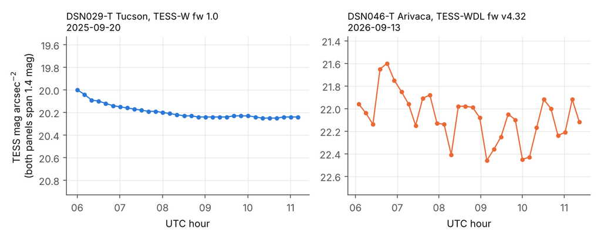

**Figure 1.** Five hours of a clear, moonless night. Left: DSN029-T (TESS-W, firmware 1.0), 2025-09-20. Right: DSN046-T (TESS-WDL, v4.32), 2026-09-13. Both panels span 1.4 mag. The TESS-W follows the smooth dimming of the city sky after midnight; the TESS-WDL jumps by up to 0.5 mag between consecutive readings at a dark site.

## 2. Jump size against sky brightness

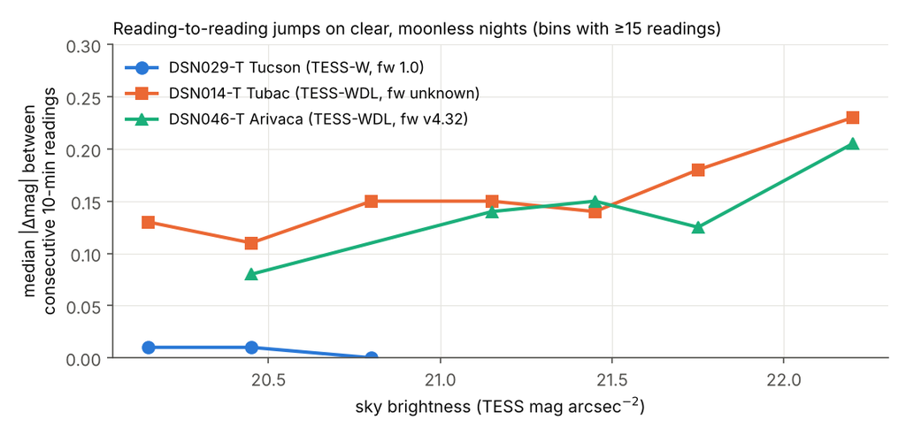

**Figure 2.** Median absolute change between consecutive readings on clear, moonless nights, in bins with at least 15 readings. The two TESS-WDL units are noisy at every brightness, including 20.0–20.6 mag, where the TESS-W receives a similar light level and is quiet. The Tucson curve ends at 21 mag because the city sky is never darker than that.

| Unit | TESS mag bin | Readings | Median jump (mag) | Share of jumps > 0.1 mag |
| --- | --- | --- | --- | --- |
| DSN029-T Tucson (TESS-W) | 20.0–20.3 | 6040 | 0.01 | 4% |
| DSN029-T Tucson (TESS-W) | 20.3–20.6 | 1657 | 0.01 | 2% |
| DSN029-T Tucson (TESS-W) | 20.6–21.0 | 49 | 0.00 | 0% |
| DSN014-T Tubac (TESS-WDL) | 20.0–20.3 | 45 | 0.13 | 58% |
| DSN014-T Tubac (TESS-WDL) | 20.3–20.6 | 86 | 0.11 | 56% |
| DSN014-T Tubac (TESS-WDL) | 20.6–21.0 | 122 | 0.15 | 64% |
| DSN014-T Tubac (TESS-WDL) | 21.0–21.3 | 178 | 0.15 | 64% |
| DSN014-T Tubac (TESS-WDL) | 21.3–21.6 | 269 | 0.14 | 56% |
| DSN014-T Tubac (TESS-WDL) | 21.6–21.9 | 294 | 0.18 | 61% |
| DSN014-T Tubac (TESS-WDL) | 21.9–22.5 | 158 | 0.23 | 65% |
| DSN046-T Arivaca (TESS-WDL) | 20.3–20.6 | 20 | 0.08 | 45% |
| DSN046-T Arivaca (TESS-WDL) | 21.0–21.3 | 32 | 0.14 | 62% |
| DSN046-T Arivaca (TESS-WDL) | 21.3–21.6 | 102 | 0.15 | 61% |
| DSN046-T Arivaca (TESS-WDL) | 21.6–21.9 | 92 | 0.12 | 62% |
| DSN046-T Arivaca (TESS-WDL) | 21.9–22.5 | 82 | 0.20 | 80% |

## 3. Tubac: TESS-WDL against the co-located SQM

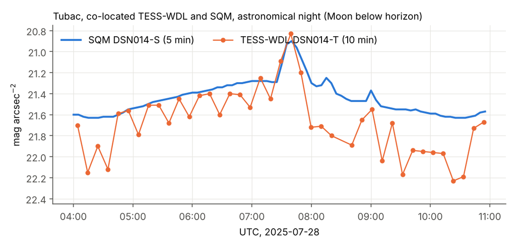

**Figure 3.** One astronomical night at Tubac, 2025-07-28 UTC. The SQM (blue, 5-minute cadence) changes smoothly; consecutive SQM readings differ by a median of 0.01 mag on clear nights. The TESS-WDL (orange) touches the SQM curve only occasionally and otherwise reads fainter by up to 0.6 mag. Both instruments record the same brief brightening near 07:40 UTC.

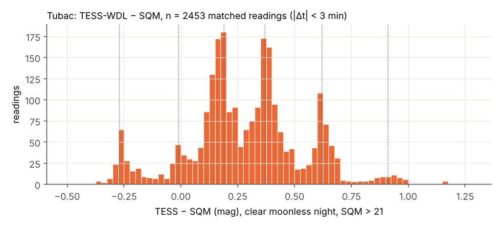

**Figure 4.** TESS − SQM for 2,453 matched clear, moonless readings with SQM > 21. Dotted lines mark the floor and the main peaks.

- **Floor.** There is a sharp lower edge at −0.27 mag and nothing below −0.38. At its brightest the TESS reads 0.27 mag brighter than the SQM, the sign expected from the redder TESS passband. Only 7% of dark readings fall near the floor.
- **Preferred levels.** Above the floor the readings cluster at about −0.01, +0.19, +0.37, +0.62 and +0.91 mag, which is 79%, 65%, 55%, 44% and 34% of the floor flux. The peaks stay at the same offsets for SQM values from 21.0 to 21.8, so the losses are fixed fractions of the signal, not a fixed amount of light.
- **Growth with darkness.** The median offset is +0.07 mag for SQM 20.5–21.0, +0.19 for 21.0–21.3, +0.35 for 21.3–21.6 and +0.39 for 21.6–22.0.
- **Not weather.** The jumps do not correlate with the TESS sky temperature (r = 0.03) and occur on nights that are clear in the SQM record.

## Consequences for users

- Nightly or weekly medians of dark-sky TESS-WDL readings come out 0.2–0.4 mag too faint, because the errors go almost only one way. Taking the brightest reading in each hour reduces the bias but does not remove it.
- Any cloud screening based on the scatter of the light curve marks clear nights as cloudy. On the Arivaca night in Figure 1, which shows a smooth underlying trend and no extended brightenings, our χ² is 0.08–0.3 for about four hours.
- Without a co-located reference the problem looks like ordinary noise, so other TESS-WDL owners may not be aware of it.

## What we cannot separate, and questions

In our network the model and the firmware change together, so we cannot tell whether the cause is the TESS-WDL hardware or the firmware. We would be grateful for answers to these questions:

1. Is this behavior known for TESS-WDL units or for firmware v4.32?
2. How is each 10-minute value formed in v4.32: a single frequency or period measurement, or an average? What integration window is used at low light levels, where the sensor gives less than one pulse per second?
3. Can a TESS-WDL run other firmware, or can an older TESS-W run v4.32, so that hardware and firmware can be tested separately?
4. Why does DSN014-T report its firmware as "unknown"?

We can supply the full reading files for all three units and the SQM file for Tubac, and we are glad to run tests on our units.